# Basketball Game Key moments Exploration (NBA 2021/22, Phoenix Suns)

Nacho Krukovsky, email: nacho.krukovsky@gmail.com

2022-05-10

## Synopsis

In this report we aim to determine the presence and impact of key moments on game outcomes based on the 2021/22 NBA regular season. We determine key moment as a moment from which the team increases or decreases the scoring rate. Our investigations are based on ‘Phoenix Suns’ games in the NBA 2021/22 regular season. All the raw data has been taken from [basketball-reference.com](https://www.basketball-reference.com/).

### Preparations

First we prepare environment for the investigation

```r
library(knitr)
library('ggspectra')
library("ggpmisc")
library("lubridate")
library(dplyr)
library(ggplot2)
```

## Load and preprocessing data

From the [Basketball reference site](https://www.basketball-reference.com/) we obtained game summary and detailed game logs of the regular season 2021/22.

```r
gameLog <- readRDS("NBA2122.RData")
```

Game summary example:

| date | place | team1 | team2 | score1 | score2 | winner1 | winner2 |
| --- | --- | --- | --- | --- | --- | --- | --- |
| 10:00 PM, October 22, 2021 | Crypto.com Arena, Los Angeles, California | Phoenix Suns | Los Angeles Lakers | 115 | 105 | 1 | 0 |

Example of the game log with first 20 tracked events is presented below:

| Time | Phoenix | LA Lakers | score1 | score2 |
| --- | --- | --- | --- | --- |
| 0 | Jump ball: D. Ayton vs. D. Jordan (A. Davis gains possession) | Jump ball: D. Ayton vs. D. Jordan (A. Davis gains possession) | 0 | 0 |
| 22 |  | L. James misses 2-pt jump shot from 16 ft | 0 | 0 |
| 28 | Defensive rebound by D. Ayton |  | 0 | 0 |
| 36 | D. Ayton misses 2-pt layup from 10 ft |  | 0 | 0 |
| 40 | Offensive rebound by D. Ayton |  | 0 | 0 |
| 40 | D. Ayton misses 2-pt layup at rim (block by R. Westbrook) |  | 0 | 0 |
| 42 |  | Defensive rebound by K. Bazemore | 0 | 0 |
| 49 |  | A. Davis misses 2-pt jump shot from 10 ft | 0 | 0 |
| 54 | Defensive rebound by D. Ayton |  | 0 | 0 |
| 69 | J. Crowder makes 2-pt jump shot from 9 ft (assist by C. Paul) |  | 2 | 0 |
| 81 |  | R. Westbrook misses 2-pt jump shot from 12 ft | 2 | 0 |
| 83 | Defensive rebound by D. Booker |  | 2 | 0 |
| 90 | M. Bridges makes 3-pt jump shot from 23 ft (assist by D. Booker) |  | 5 | 0 |
| 110 |  | R. Westbrook makes 2-pt jump shot from 19 ft (assist by D. Jordan) | 5 | 2 |
| 127 | J. Crowder makes 2-pt jump shot from 10 ft (assist by C. Paul) |  | 7 | 2 |
| 137 |  | L. James misses 2-pt jump shot from 16 ft | 7 | 2 |
| 141 | Defensive rebound by C. Paul |  | 7 | 2 |
| 145 | J. Crowder misses 3-pt jump shot from 26 ft |  | 7 | 2 |
| 145 | Offensive rebound by M. Bridges |  | 7 | 2 |
| 148 | Turnover by D. Booker (out of bounds lost ball) |  | 7 | 2 |

## Explorations

Observing the game log we calculate average points rate per minute for both teams called ‘ppm1’ and ‘ppm2’ and plot an average ppm graph. We omit first 120 seconds of each game as ppm in the beginning of the game has huge deviations and distorts trends. Considering our example ppm graph of Phoenix Suns in particular game is looking like:

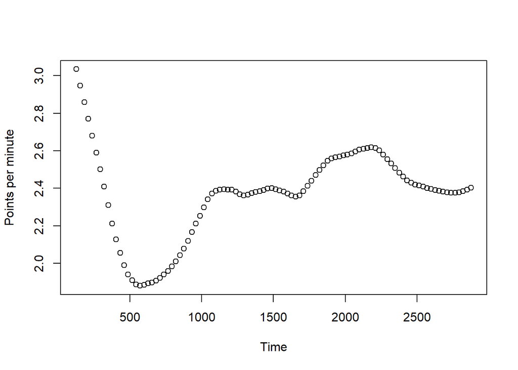

```r
game_log_p <- gameLog[[25]][[2]] %>% filter(Time > 120)


# Smooth raw data to a graph
smt1 <- loess.smooth(game_log_p$Time, game_log_p$ppm1, span=0.2,
                     degree = 2, evaluation = 100)
plot(smt1, xlab = "Time", ylab = "Points per minute")
```

As we can see the graph is not straight. The pace of scoring had changed several times during the game. We determine these moments as key moments. Now we mark them with red and green points:

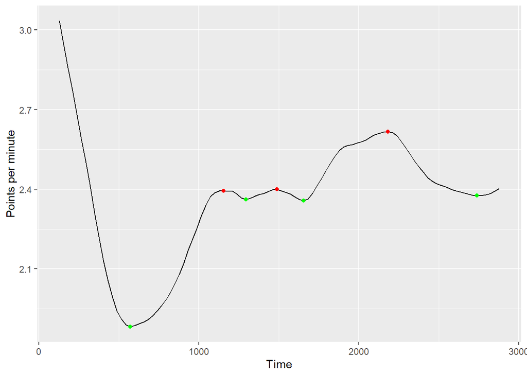

On the plot we see seven points plus the start and the end of the graph (total nine points).  
This study does not take into account the key moments of the opponent, although this undoubtedly affects the result of the game as well. The causes of key moments is also the subject of another investigation. In this report we’re going to explore the impact of the number of key moments to the game results of Phoenix Suns.

For this we calculate the number of key moments and win/loss flag for each Suns game in the regular season:

```
## [1] "English_United States.1252"
```

```
##          date sWinner peakCount
## 1  2021-10-20       0        11
## 2  2021-10-22       1         9
## 3  2021-10-23       0        14
## 4  2021-10-27       0        10
## 5  2021-10-30       1        11
## 6  2021-12-02       1        10
## 7  2021-12-03       0        10
## 8  2021-12-06       1         7
## 9  2021-12-10       1        10
## 10 2021-12-13       0        12
## 11 2021-12-14       1         9
## 12 2021-12-16       1        13
## 13 2021-12-19       1         9
## 14 2021-12-21       1         7
```

[output cut: 55 more lines]

Сheck the relationship between the number of key moments (peakCount) and wins/losses(sWinner) for the Suns:

```r
# Create general linear model
logPhx = glm(sWinner ~ peakCount, data = teamPeaks, family="binomial")
summary(logPhx)
```

```
##
## Call:
## glm(formula = sWinner ~ peakCount, family = "binomial", data = teamPeaks)
##
## Deviance Residuals:
##     Min       1Q   Median       3Q      Max
## -1.9709  -1.3289   0.7423   0.7955   1.0981
##
## Coefficients:
##             Estimate Std. Error z value Pr(>|z|)
## (Intercept)   2.5865     1.3843   1.868   0.0617 .
## peakCount    -0.1598     0.1322  -1.209   0.2267
## ---
## Signif. codes:  0 '***' 0.001 '**' 0.01 '*' 0.05 '.' 0.1 ' ' 1
##
## (Dispersion parameter for binomial family taken to be 1)
##
##     Null deviance: 81.216  on 68  degrees of freedom
## Residual deviance: 79.735  on 67  degrees of freedom
## AIC: 83.735
##
## Number of Fisher Scoring iterations: 4
```

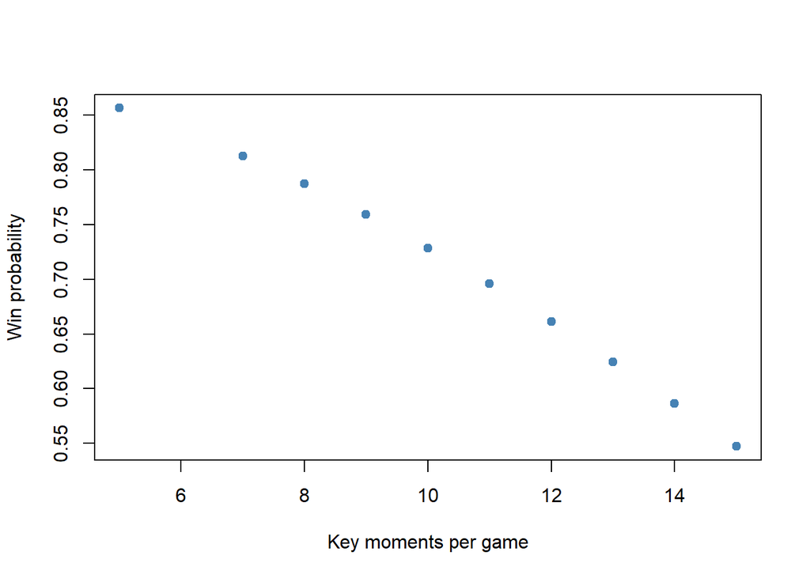

```r
# Plot model
plot(teamPeaks$peakCount,logPhx$fitted,pch=19,col="steelblue",xlab="Key moments per game",ylab ="Win probability")
```

Finally we plot the win probability graph with confidence interval:

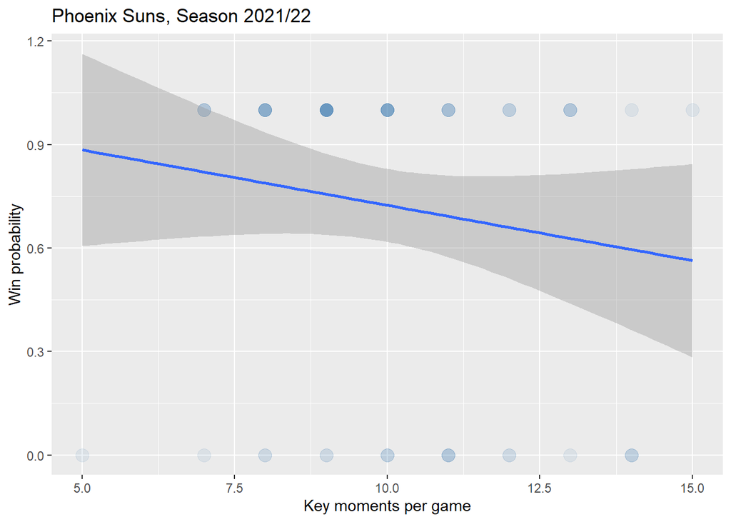

```r
# Plot base graph with confidence interval
p3 <- ggplot(data = teamPeaks, aes(x = peakCount, y = sWinner))
p3 <- p3 + geom_point(color = "steelblue", size = 4, alpha = 0.1)+ geom_smooth(method = "glm")
p3 + labs(title = "Phoenix Suns, Season 2021/22", x = "Key moments per game", y = "Win probability")
```

## Further investigations

Subjects of investigations:

- Impact of the other factors such as the opponent key moments, home/away game, team lineup and summary stats to the win/lose probability.
- Investigation of the causes of key events.